# Project: TMDB Data Analysis

- Introduction
- Data Wrangling
- Exploratory Data Analysis and answer some questions
- Conclusions

## Introduction

> This dataset contains information about movies released from 1960 to 2015. Our goal is to do some analysis to see relationships between its columns. and answer some question. Our questions:

> Q1: What is the change in each of (genres, popularity, budget, revenue, number of movies produced, number of succeeded and failed movies, vote counts, vote average) through years from 1960 to 2015

> Q2: What is the most popular months, most months having high budget and revenue ?

> Q3: Whats is the movie that has the highest popularity of each year since 1960 ?

> Q4: Whats is the movie that has the highest revenue of each year since 1960 ?

> Q5: Whats is the movie that has the highest budget of each year since 1960 ?

> Q6: Whats is the movie that has the highest vote of each year since 1960 ?

> Q7: What is the genre that has the highest movies released each year?

## Q8 What is the relationship between vote average and popularity, and btween succeeded movies and popularity ?

```python
#import important libraries

import numpy as np
import pandas as pd
import matplotlib.pyplot as plt
import seaborn as sns
%matplotlib inline
```

## Data Wrangling

> In this section, we will load in the data, check for cleanliness, and then clean our dataset for analysis.

```python
# load our dataset

df = pd.read_csv("tmdb-movies.csv")
```

```python
# show first 5 rows

df.head(5)
```

|  | id | imdb_id | popularity | budget | revenue | original_title | cast | homepage | director | tagline | ... | overview | runtime | genres | production_companies | release_date | vote_count | vote_average | release_year | budget_adj | revenue_adj |
| --- | --- | --- | --- | --- | --- | --- | --- | --- | --- | --- | --- | --- | --- | --- | --- | --- | --- | --- | --- | --- | --- |
| 0 | 135397 | tt0369610 | 32.985763 | 150000000 | 1513528810 | Jurassic World | Chris Pratt\|Bryce Dallas Howard\|Irrfan Khan\|Vi... | http://www.jurassicworld.com/ | Colin Trevorrow | The park is open. | ... | Twenty-two years after the events of Jurassic ... | 124 | Action\|Adventure\|Science Fiction\|Thriller | Universal Studios\|Amblin Entertainment\|Legenda... | 6/9/15 | 5562 | 6.5 | 2015 | 1.379999e+08 | 1.392446e+09 |
| 1 | 76341 | tt1392190 | 28.419936 | 150000000 | 378436354 | Mad Max: Fury Road | Tom Hardy\|Charlize Theron\|Hugh Keays-Byrne\|Nic... | http://www.madmaxmovie.com/ | George Miller | What a Lovely Day. | ... | An apocalyptic story set in the furthest reach... | 120 | Action\|Adventure\|Science Fiction\|Thriller | Village Roadshow Pictures\|Kennedy Miller Produ... | 5/13/15 | 6185 | 7.1 | 2015 | 1.379999e+08 | 3.481613e+08 |
| 2 | 262500 | tt2908446 | 13.112507 | 110000000 | 295238201 | Insurgent | Shailene Woodley\|Theo James\|Kate Winslet\|Ansel... | http://www.thedivergentseries.movie/#insurgent | Robert Schwentke | One Choice Can Destroy You | ... | Beatrice Prior must confront her inner demons ... | 119 | Adventure\|Science Fiction\|Thriller | Summit Entertainment\|Mandeville Films\|Red Wago... | 3/18/15 | 2480 | 6.3 | 2015 | 1.012000e+08 | 2.716190e+08 |
| 3 | 140607 | tt2488496 | 11.173104 | 200000000 | 2068178225 | Star Wars: The Force Awakens | Harrison Ford\|Mark Hamill\|Carrie Fisher\|Adam D... | http://www.starwars.com/films/star-wars-episod... | J.J. Abrams | Every generation has a story. | ... | Thirty years after defeating the Galactic Empi... | 136 | Action\|Adventure\|Science Fiction\|Fantasy | Lucasfilm\|Truenorth Productions\|Bad Robot | 12/15/15 | 5292 | 7.5 | 2015 | 1.839999e+08 | 1.902723e+09 |
| 4 | 168259 | tt2820852 | 9.335014 | 190000000 | 1506249360 | Furious 7 | Vin Diesel\|Paul Walker\|Jason Statham\|Michelle ... | http://www.furious7.com/ | James Wan | Vengeance Hits Home | ... | Deckard Shaw seeks revenge against Dominic Tor... | 137 | Action\|Crime\|Thriller | Universal Pictures\|Original Film\|Media Rights ... | 4/1/15 | 2947 | 7.3 | 2015 | 1.747999e+08 | 1.385749e+09 |

5 rows × 21 columns

```python
# take a quick describtion of our dataset

df.describe()
```

|  | id | popularity | budget | revenue | runtime | vote_count | vote_average | release_year | budget_adj | revenue_adj |
| --- | --- | --- | --- | --- | --- | --- | --- | --- | --- | --- |
| count | 10866.000000 | 10866.000000 | 1.086600e+04 | 1.086600e+04 | 10866.000000 | 10866.000000 | 10866.000000 | 10866.000000 | 1.086600e+04 | 1.086600e+04 |
| mean | 66064.177434 | 0.646441 | 1.462570e+07 | 3.982332e+07 | 102.070863 | 217.389748 | 5.974922 | 2001.322658 | 1.755104e+07 | 5.136436e+07 |
| std | 92130.136561 | 1.000185 | 3.091321e+07 | 1.170035e+08 | 31.381405 | 575.619058 | 0.935142 | 12.812941 | 3.430616e+07 | 1.446325e+08 |
| min | 5.000000 | 0.000065 | 0.000000e+00 | 0.000000e+00 | 0.000000 | 10.000000 | 1.500000 | 1960.000000 | 0.000000e+00 | 0.000000e+00 |
| 25% | 10596.250000 | 0.207583 | 0.000000e+00 | 0.000000e+00 | 90.000000 | 17.000000 | 5.400000 | 1995.000000 | 0.000000e+00 | 0.000000e+00 |
| 50% | 20669.000000 | 0.383856 | 0.000000e+00 | 0.000000e+00 | 99.000000 | 38.000000 | 6.000000 | 2006.000000 | 0.000000e+00 | 0.000000e+00 |
| 75% | 75610.000000 | 0.713817 | 1.500000e+07 | 2.400000e+07 | 111.000000 | 145.750000 | 6.600000 | 2011.000000 | 2.085325e+07 | 3.369710e+07 |
| max | 417859.000000 | 32.985763 | 4.250000e+08 | 2.781506e+09 | 900.000000 | 9767.000000 | 9.200000 | 2015.000000 | 4.250000e+08 | 2.827124e+09 |

```python
# see the types of our columns and how many nulls

df.info()
```

```
<class 'pandas.core.frame.DataFrame'>
RangeIndex: 10866 entries, 0 to 10865
Data columns (total 21 columns):
 #   Column                Non-Null Count  Dtype
---  ------                --------------  -----
 0   id                    10866 non-null  int64
 1   imdb_id               10856 non-null  object
 2   popularity            10866 non-null  float64
 3   budget                10866 non-null  int64
 4   revenue               10866 non-null  int64
 5   original_title        10866 non-null  object
 6   cast                  10790 non-null  object
 7   homepage              2936 non-null   object
 8   director              10822 non-null  object
 9   tagline               8042 non-null   object
 10  keywords              9373 non-null   object
 11  overview              10862 non-null  object
 12  runtime               10866 non-null  int64
 13  genres                10843 non-null  object
 14  production_companies  9836 non-null   object
 15  release_date          10866 non-null  object
 16  vote_count            10866 non-null  int64
 17  vote_average          10866 non-null  float64
 18  release_year          10866 non-null  int64
 19  budget_adj            10866 non-null  float64
 20  revenue_adj           10866 non-null  float64
dtypes: float64(4), int64(6), object(11)
memory usage: 1.7+ MB
```

###### We can see that there are many nulls in some columns.

###### We can not remove nulls now as we will lose 75% of our data because of the too many nulls in homepage column

###### So we have to remove some columns that are not important in our analysis and will affect nothing

## id, imdb_id, homepage, tagline, keywords, overview

```python
# print our columns

df.columns
```

```
Index(['id', 'imdb_id', 'popularity', 'budget', 'revenue', 'original_title',
       'cast', 'homepage', 'director', 'tagline', 'keywords', 'overview',
       'runtime', 'genres', 'production_companies', 'release_date',
       'vote_count', 'vote_average', 'release_year', 'budget_adj',
       'revenue_adj'],
      dtype='object')
```

```python
# lets drop some unnecessary columns

df.drop(['id', 'imdb_id', 'homepage', 'tagline', 'keywords', 'overview'], axis=1, inplace=True)
```

```python
# print the shape of our datafram after dropping 6 columns

df.shape
```

```
(10866, 15)
```

### Now we can remove nulls and duplicates

```python
# remove rows that contain any null

df.dropna(inplace=True)
```

```python
# print the shape of our datafram after removing rows containing nulls

df.shape
```

```
(9773, 15)
```

```python
# lets drop duplicates from our dataset

df.drop_duplicates(inplace=True)
```

```python
# print the shape of our datafram after dropping duplicates

df.shape
```

```
(9772, 15)
```

```python
# from seeing the dataset , we can observe that there are many zeros in budget and revenue columns
# print how many rows contains zero

sum(df.budget==0)
```

```
4751
```

```python
sum(df.revenue==0)
```

```
5022
```

### Lets add month column and simplify genres column and take the first genre only.

```python
# release_date column has 3 numbers seperated by "/", the first number is of the month

df['month']=df.release_date.apply(lambda x : x.split("/")[0])
```

```python
# convert month column from string to int

df.month = df.month.astype('int')
```

```python
# genres column contains many genres separated by "|"
# i will make a new column contains only the first genre, i will make col name "genres2"

df['genres2']=df.genres.apply(lambda x : x if x.find("|")==False else x.split("|")[0])
```

### Let's take a quick view of our columns histograms

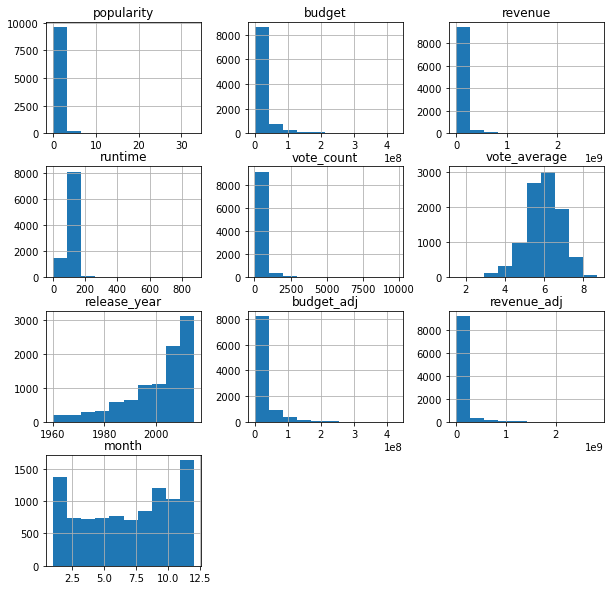

```python
df.hist(figsize=(10,10));
```

### Lets see it in more details by increasing number of bins

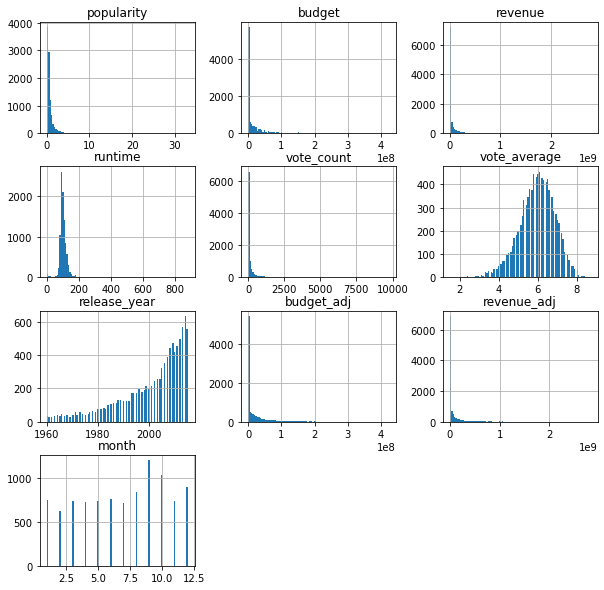

```python
df.hist(bins=100,figsize=(10,10));
```

### We can see that budget and revenue having too many 0.

### We can add a new column to detect the difference between the money paid ( budget ) to the money came back ( revenue )

```python
df['revenue_budget_diff'] = df['revenue'] - df['budget']
```

### Succeeded movie is the movie when the revenue is greater than the budget

```python
df['succeeded_movie'] = df['revenue_budget_diff'] > 0
```

```python
# the col we made above "succeeded_movie" will have true and false values
# lets make a new col that have 1 and 0 instead , col name = "succeeded_movie2"

df['succeeded_movie2'] = 1
df['succeeded_movie2'][df['succeeded_movie']==False] = 0
```

# Our data is clean now, we can use it to analyze and answer some questions

# Exploratory Data Analysis

### In this section we are going to analyze some data and get some conclusions and answer some questions

Our questions:

Q1: What is the change in each of (genres, popularity, budget, revenue, number of movies produced, number of succeeded and failed movies, vote counts, vote average) through years from 1960 to 2015

Q2: What is the most popular months, most months having high budget and revenue ?

Q3: Whats is the movie that has the highest popularity of each year since 1960 ?

Q4: Whats is the movie that has the highest revenue of each year since 1960 ?

Q5: Whats is the movie that has the highest budget of each year since 1960 ?

Q6: Whats is the movie that has the highest vote of each year since 1960 ?

Q7: What is the genre that has the highest movies released each year?

## Q8 What is the relationship between vote average and popularity, and btween succeeded movies and popularity ?

# Q1: What is the change in each of (genres, popularity, budget, revenue, number of movies produced, number of succeeded and failed movies, vote counts, vote average) through years from 1960 to 2015

```python
# print columns names after adding and dropping some of them

df.columns
```

```
Index(['popularity', 'budget', 'revenue', 'original_title', 'cast', 'director',
       'runtime', 'genres', 'production_companies', 'release_date',
       'vote_count', 'vote_average', 'release_year', 'budget_adj',
       'revenue_adj', 'month', 'genres2', 'revenue_budget_diff',
       'succeeded_movie', 'succeeded_movie2'],
      dtype='object')
```

```python
# lets group our data in term of the release date
# and find the min, max, average, summation of some columns as
# popularity        >>>>    lets find it's min, max, mean, sum
# original_title    >>>>    lets find it's count which indicates how many movies released on this year
# succeeded_movie   >>>>    lets find sum which indicates how many movies succeeded on this year
# budget            >>>>    lets find it's min, max, mean, sum
# revenue           >>>>    lets find it's min, max, mean, sum
# vote_count        >>>>    lets find it's sum
# runtime           >>>>    lets find it's min, max, mean, sum
# vote_average      >>>>    lets find it's min, max, mean
# genres2           >>>>    lets find it's mode

df2 = df.groupby('release_year').agg({'popularity':['min','max','mean','sum'],'original_title':'count','succeeded_movie':'sum','budget':['min','max','mean','sum'], 'revenue':['min','max','mean','sum'],'vote_count':'sum', 'runtime':['min','max','mean','sum'],'vote_average':['min','max','mean'],'genres2':pd.Series.mode})
```

ref: https://pbpython.com/groupby-agg.html

```python
# add a column to the number of failed movies in each year
# add a column contains the difference between the summation of revenues and budgets

df2['failed_movies'] = df2[( 'original_title', 'count')] - df2[('succeeded_movie',   'sum')]
df2['revenue_budget_diff'] = df2[('revenue', 'sum')] - df2[('budget', 'sum')]
```

I used the next lines to show the data left aligned, ref: https://stackoverflow.com/questions/17232013/how-to-set-the-pandas-dataframe-data-left-right-alignment

```python
# show the new dataframe but in left aligned style

dfStyler = df2.style.set_properties(**{'text-align': 'left'})
dfStyler.set_table_styles([dict(selector='th', props=[('text-align', 'left')])])
```

| release_year | popularity min | popularity max | popularity mean | popularity sum | original_title count | succeeded_movie sum | budget min | budget max | budget mean | budget sum | revenue min | revenue max | revenue mean | revenue sum | vote_count sum | runtime min | runtime max | runtime mean | runtime sum | vote_average min | vote_average max | vote_average mean | genres2 mode | failed_movies | revenue_budget_diff |
| --- | --- | --- | --- | --- | --- | --- | --- | --- | --- | --- | --- | --- | --- | --- | --- | --- | --- | --- | --- | --- | --- | --- | --- | --- | --- |
| 1960 | 0.055821 | 2.610362 | 0.458932 | 14.685834 | 32 | 7 | 0 | 12000000 | 689279.625000 | 22056948 | 0 | 60000000 | 4531406.250000 | 145005000 | 2481 | 70 | 208 | 110.656250 | 3541 | 4.900000 | 8.000000 | 6.325000 | Action | 25 | 122948052 |
| 1961 | 0.027527 | 2.631987 | 0.430438 | 12.913146 | 30 | 9 | 0 | 6000000 | 1537900.000000 | 46137000 | 0 | 215880014 | 11257339.600000 | 337720188 | 2395 | 79 | 186 | 119.866667 | 3596 | 5.200000 | 7.500000 | 6.433333 | Comedy | 21 | 291583188 |
| 1962 | 0.038819 | 3.170651 | 0.465245 | 13.957338 | 30 | 9 | 0 | 15000000 | 1824070.866667 | 54722126 | 0 | 70000000 | 7185994.866667 | 215579846 | 2364 | 78 | 216 | 125.833333 | 3775 | 4.900000 | 7.700000 | 6.386667 | Drama | 21 | 160857720 |
| 1963 | 0.045417 | 2.508235 | 0.502706 | 17.092019 | 34 | 6 | 0 | 31115000 | 2156808.823529 | 73331500 | 0 | 78898765 | 5511911.441176 | 187404989 | 2816 | 18 | 248 | 111.323529 | 3785 | 5.000000 | 7.500000 | 6.329412 | Comedy | 28 | 114073489 |
| 1964 | 0.008990 | 3.153791 | 0.421091 | 17.264746 | 41 | 8 | 0 | 17000000 | 963003.926829 | 39483161 | 0 | 124900000 | 8316628.829268 | 340981782 | 3126 | 52 | 170 | 111.195122 | 4559 | 4.600000 | 7.700000 | 6.224390 | ['Comedy' 'Drama'] | 33 | 301498621 |
| 1965 | 0.014759 | 1.910465 | 0.352522 | 11.985759 | 34 | 4 | 0 | 20000000 | 2064856.323529 | 70205115 | 0 | 163214286 | 13472995.705882 | 458081854 | 1810 | 25 | 199 | 119.294118 | 4056 | 4.400000 | 7.600000 | 6.188235 | Drama | 30 | 387876739 |
| 1966 | 0.034555 | 1.227582 | 0.308457 | 13.572123 | 44 | 5 | 0 | 18000000 | 1308063.636364 | 57554800 | 0 | 33736689 | 1925833.840909 | 84736689 | 1422 | 25 | 182 | 108.590909 | 4778 | 1.500000 | 7.500000 | 6.086364 | Action | 39 | 27181889 |
| 1967 | 0.054432 | 2.550704 | 0.511007 | 18.396240 | 36 | 12 | 0 | 25000000 | 2795888.888889 | 100652000 | 0 | 205843612 | 20495406.583333 | 737834637 | 3046 | 78 | 152 | 109.416667 | 3939 | 4.600000 | 7.600000 | 6.319444 | Comedy | 24 | 637182637 |
| 1968 | 0.005265 | 3.309196 | 0.506612 | 18.744652 | 37 | 11 | 0 | 12000000 | 1944297.297297 | 71939000 | 0 | 56715371 | 7154945.405405 | 264732980 | 4194 | 4 | 155 | 110.540541 | 4090 | 5.400000 | 7.700000 | 6.370270 | Drama | 26 | 192793980 |
| 1969 | 0.021121 | 1.778746 | 0.441299 | 12.797661 | 29 | 4 | 0 | 12000000 | 1452727.137931 | 42129087 | 0 | 102308889 | 8412312.965517 | 243957076 | 1702 | 25 | 158 | 110.310345 | 3199 | 3.900000 | 7.300000 | 5.944828 | Drama | 25 | 201827989 |
| 1970 | 0.020760 | 1.936962 | 0.341638 | 13.665514 | 40 | 10 | 0 | 25485000 | 3174048.650000 | 126961946 | 0 | 136400000 | 14005549.225000 | 560221969 | 2001 | 48 | 225 | 113.075000 | 4523 | 4.300000 | 7.600000 | 6.502500 | Action | 30 | 433260023 |
| 1971 | 0.000188 | 3.072555 | 0.448112 | 24.646153 | 55 | 14 | 0 | 20000000 | 1381763.636364 | 75997000 | 0 | 116000000 | 7362011.090909 | 404910610 | 5081 | 73 | 189 | 107.727273 | 5925 | 2.900000 | 7.700000 | 6.420000 | Drama | 41 | 328913610 |
| 1972 | 0.024345 | 5.738034 | 0.469449 | 17.369621 | 37 | 10 | 0 | 6000000 | 980520.378378 | 36279254 | 0 | 245066411 | 13371085.702703 | 494730171 | 5397 | 78 | 175 | 103.027027 | 3812 | 5.300000 | 8.300000 | 6.524324 | Comedy | 27 | 458450917 |
| 1973 | 0.021941 | 2.272486 | 0.494462 | 27.195419 | 55 | 17 | 0 | 15000000 | 1185286.963636 | 65190783 | 0 | 441306145 | 22254201.854545 | 1223981102 | 5173 | 25 | 151 | 103.527273 | 5694 | 4.800000 | 7.700000 | 6.703636 | Action | 38 | 1158790319 |
| 1974 | 0.029670 | 3.264571 | 0.469544 | 20.659918 | 44 | 17 | 0 | 14000000 | 1749318.181818 | 76970000 | 0 | 119500000 | 18466814.045455 | 812539818 | 5164 | 51 | 200 | 108.659091 | 4781 | 4.800000 | 8.100000 | 6.404545 | Action | 27 | 735569818 |
| 1975 | 0.017468 | 3.258151 | 0.533266 | 22.397183 | 42 | 15 | 0 | 15000000 | 1339976.190476 | 56279000 | 0 | 470654000 | 22797380.142857 | 957489966 | 6063 | 72 | 184 | 107.714286 | 4524 | 4.900000 | 8.000000 | 6.452381 | ['Action' 'Comedy'] | 27 | 901210966 |
| 1976 | 0.002381 | 2.582657 | 0.476533 | 21.920529 | 46 | 16 | 0 | 35000000 | 2655434.782609 | 122150000 | 0 | 161000000 | 17413165.217391 | 801005600 | 4710 | 86 | 139 | 109.956522 | 5058 | 4.600000 | 7.800000 | 6.371739 | Drama | 30 | 678855600 |
| 1977 | 0.046957 | 12.037933 | 0.647046 | 35.587529 | 55 | 23 | 0 | 22000000 | 2937818.181818 | 161580000 | 0 | 775398007 | 39646966.527273 | 2180583159 | 8009 | 74 | 177 | 108.327273 | 5958 | 4.600000 | 7.900000 | 6.141818 | Drama | 32 | 2019003159 |
| 1978 | 0.044675 | 1.697618 | 0.430003 | 26.230174 | 61 | 21 | 0 | 55000000 | 3426180.508197 | 208997011 | 0 | 300218018 | 22186666.540984 | 1353386659 | 4815 | 86 | 183 | 111.573770 | 6806 | 3.100000 | 8.000000 | 6.139344 | Drama | 40 | 1144389648 |
| 1979 | 0.019263 | 4.935897 | 0.597555 | 33.463055 | 56 | 25 | 0 | 35000000 | 4550250.000000 | 254814000 | 0 | 210300000 | 30085623.446429 | 1684794913 | 8816 | 88 | 184 | 112.625000 | 6307 | 3.000000 | 7.800000 | 6.296429 | Drama | 31 | 1429980913 |
| 1980 | 0.031133 | 5.488441 | 0.519920 | 37.954180 | 73 | 37 | 0 | 54000000 | 4965753.424658 | 362500000 | 0 | 538400000 | 24228251.876712 | 1768662387 | 10831 | 75 | 219 | 108.424658 | 7915 | 3.600000 | 8.000000 | 6.145205 | Action | 36 | 1406162387 |
| 1981 | 0.046679 | 4.578300 | 0.455818 | 35.553775 | 78 | 36 | 0 | 32000000 | 4343048.538462 | 338757786 | 0 | 389925971 | 22751362.000000 | 1774606236 | 7403 | 81 | 195 | 105.064103 | 8195 | 4.200000 | 8.500000 | 6.152564 | Drama | 42 | 1435848450 |
| 1982 | 0.003659 | 4.215642 | 0.547968 | 43.837470 | 80 | 40 | 0 | 50000000 | 5472437.525000 | 437795002 | 0 | 792910554 | 30730548.150000 | 2458443852 | 11372 | 6 | 191 | 104.037500 | 8323 | 3.000000 | 7.900000 | 6.230000 | Comedy | 40 | 2020648850 |
| 1983 | 0.015727 | 4.828854 | 0.555111 | 42.743561 | 77 | 45 | 0 | 40600000 | 6727368.987013 | 518007412 | 0 | 572700000 | 29967913.246753 | 2307529320 | 9823 | 26 | 197 | 104.389610 | 8038 | 2.700000 | 7.800000 | 5.951948 | Comedy | 32 | 1789521908 |
| 1984 | 0.059713 | 4.831966 | 0.611105 | 60.499364 | 99 | 46 | 0 | 58000000 | 7365777.414141 | 729211964 | 0 | 333000000 | 26621458.767677 | 2635524418 | 15237 | 29 | 229 | 104.868687 | 10382 | 3.600000 | 8.400000 | 6.010101 | Drama | 53 | 1906312454 |
| 1985 | 0.047123 | 6.095293 | 0.596628 | 63.242541 | 106 | 54 | 0 | 50000000 | 7063402.235849 | 748720637 | 0 | 381109762 | 27129928.226415 | 2875772392 | 13721 | 77 | 566 | 109.433962 | 11600 | 4.300000 | 8.300000 | 6.184906 | Comedy | 52 | 2127051755 |
| 1986 | 0.058402 | 2.485419 | 0.541604 | 59.034876 | 109 | 60 | 0 | 40000000 | 6364322.137615 | 693711113 | 0 | 356830601 | 27505202.394495 | 2998067061 | 13446 | 74 | 142 | 102.165138 | 11136 | 4.100000 | 7.600000 | 6.060550 | ['Comedy' 'Drama'] | 49 | 2304355948 |
| 1987 | 0.005529 | 3.474728 | 0.535698 | 60.533928 | 113 | 65 | 0 | 40000000 | 6278370.008850 | 709455811 | 0 | 320145693 | 30638095.991150 | 3462104847 | 14866 | 48 | 163 | 102.318584 | 11562 | 3.500000 | 7.700000 | 6.149558 | Comedy | 48 | 2752649036 |
| 1988 | 0.019075 | 3.777441 | 0.491846 | 64.923629 | 132 | 65 | 0 | 70000000 | 6991272.727273 | 922848000 | 0 | 354825435 | 28325464.848485 | 3738961360 | 14333 | 69 | 180 | 104.037879 | 13733 | 3.800000 | 8.000000 | 5.931061 | Comedy | 67 | 2816113360 |
| 1989 | 0.046709 | 4.143585 | 0.585155 | 74.899807 | 128 | 71 | 0 | 70000000 | 8434815.312500 | 1079656360 | 0 | 474171806 | 40350966.546875 | 5164923718 | 18462 | 79 | 372 | 106.250000 | 13600 | 4.000000 | 8.200000 | 6.072656 | Comedy | 57 | 4085267358 |
| 1990 | 0.024987 | 2.679627 | 0.553660 | 69.761107 | 126 | 63 | 0 | 70000000 | 10145666.865079 | 1278354025 | 0 | 505000000 | 42100703.801587 | 5304688679 | 21477 | 23 | 192 | 105.880952 | 13341 | 3.800000 | 8.000000 | 5.967460 | Drama | 63 | 4026334654 |
| 1991 | 0.048237 | 3.852269 | 0.515138 | 64.392295 | 125 | 53 | 0 | 100000000 | 11729864.000000 | 1466233000 | 0 | 520000000 | 37652798.368000 | 4706599796 | 16857 | 75 | 236 | 105.768000 | 13221 | 3.100000 | 7.900000 | 6.050400 | Drama | 72 | 3240366796 |
| 1992 | 0.028515 | 4.586426 | 0.606111 | 76.369949 | 126 | 69 | 0 | 80000000 | 11375599.507937 | 1433325538 | 0 | 504050219 | 48239311.246032 | 6078153217 | 19265 | 76 | 202 | 108.182540 | 13631 | 4.400000 | 7.900000 | 6.046825 | Drama | 57 | 4644827679 |
| 1993 | 0.014992 | 2.571339 | 0.560883 | 96.471923 | 172 | 84 | 0 | 85000000 | 10335050.308140 | 1777628653 | 0 | 920100000 | 40419671.505814 | 6952183499 | 24199 | 30 | 254 | 107.744186 | 18532 | 3.400000 | 8.100000 | 6.038953 | Drama | 88 | 5174554846 |
| 1994 | 0.061916 | 8.093754 | 0.696182 | 121.135741 | 174 | 65 | 0 | 115000000 | 12759810.528736 | 2220207032 | 0 | 788241776 | 40753324.155172 | 7091078403 | 37342 | 69 | 366 | 107.850575 | 18766 | 3.900000 | 8.400000 | 5.940230 | Comedy | 109 | 4870871371 |
| 1995 | 0.052554 | 4.765359 | 0.728288 | 123.808879 | 170 | 74 | 0 | 175000000 | 16658143.394118 | 2831884377 | 0 | 1106279658 | 53807432.594118 | 9147263541 | 35696 | 30 | 300 | 108.335294 | 18417 | 3.500000 | 8.500000 | 6.072353 | Drama | 96 | 6315379164 |
| 1996 | 0.028143 | 4.480733 | 0.618728 | 121.270649 | 196 | 75 | 0 | 100000000 | 18730000.000000 | 3671080000 | 0 | 816969268 | 42366643.214286 | 8303862070 | 25789 | 73 | 242 | 106.336735 | 20842 | 3.300000 | 7.600000 | 5.867857 | Comedy | 121 | 4632782070 |
| 1997 | 0.022145 | 4.355219 | 0.703757 | 126.676286 | 180 | 79 | 0 | 200000000 | 26394925.972222 | 4751086675 | 0 | 1845034188 | 59193886.611111 | 10654899590 | 40731 | 4 | 273 | 107.594444 | 19367 | 3.200000 | 7.800000 | 5.997778 | ['Action' 'Comedy'] | 101 | 5903812915 |
| 1998 | 0.037178 | 4.180540 | 0.662964 | 126.626105 | 191 | 73 | 0 | 140000000 | 23524397.905759 | 4493160000 | 0 | 553799566 | 49653752.874346 | 9483866799 | 39630 | 44 | 178 | 104.774869 | 20012 | 2.900000 | 8.000000 | 5.983246 | Comedy | 118 | 4990706799 |
| 1999 | 0.034182 | 8.947905 | 0.673304 | 142.740512 | 212 | 81 | 0 | 170000000 | 27100165.594340 | 5745235106 | 0 | 924317558 | 53564681.976415 | 11355712579 | 53247 | 33 | 189 | 107.650943 | 22822 | 3.400000 | 8.100000 | 6.052358 | Comedy | 131 | 5610477473 |
| 2000 | 0.005784 | 4.271452 | 0.601602 | 117.914036 | 196 | 76 | 0 | 127500000 | 29266326.530612 | 5736200000 | 0 | 546388105 | 55709286.765306 | 10919020206 | 45531 | 3 | 292 | 104.750000 | 20531 | 3.500000 | 7.900000 | 5.866837 | Comedy | 120 | 5182820206 |
| 2001 | 0.026783 | 8.575419 | 0.771896 | 163.642052 | 212 | 89 | 0 | 140000000 | 26504853.773585 | 5619029000 | 0 | 976475550 | 63017774.367925 | 13359768166 | 62447 | 3 | 705 | 108.990566 | 23106 | 3.700000 | 8.000000 | 5.907547 | Comedy | 123 | 7740739166 |
| 2002 | 0.017708 | 8.095275 | 0.750044 | 180.760677 | 241 | 96 | 0 | 140000000 | 24181079.896266 | 5827640255 | 0 | 926287400 | 60648309.161826 | 14616242508 | 62392 | 5 | 877 | 106.518672 | 25671 | 3.300000 | 8.300000 | 5.950207 | Comedy | 145 | 8788602253 |
| 2003 | 0.013546 | 7.122455 | 0.768583 | 195.220074 | 254 | 105 | 0 | 200000000 | 24511249.582677 | 6225857394 | 0 | 1118888979 | 59563472.322835 | 15129121970 | 67884 | 5 | 352 | 100.818898 | 25608 | 3.400000 | 8.000000 | 5.925197 | Comedy | 149 | 8903264576 |
| 2004 | 0.022891 | 5.827781 | 0.825507 | 208.853145 | 253 | 108 | 0 | 200000000 | 27948973.209486 | 7071090222 | 0 | 919838758 | 66195538.936759 | 16747471351 | 78044 | 5 | 184 | 103.632411 | 26219 | 2.100000 | 7.800000 | 5.963636 | Drama | 145 | 9676381129 |
| 2005 | 0.000973 | 5.939927 | 0.677563 | 218.852967 | 323 | 134 | 0 | 207000000 | 22582923.681115 | 7294284349 | 0 | 895921036 | 51100004.102167 | 16505301325 | 72404 | 11 | 240 | 104.470588 | 33744 | 2.500000 | 8.200000 | 5.820433 | Comedy | 189 | 9211016976 |
| 2006 | 0.001115 | 5.838503 | 0.665477 | 232.917076 | 350 | 146 | 0 | 270000000 | 20682243.714286 | 7238785300 | 0 | 1065659812 | 46432852.000000 | 16251498200 | 74502 | 0 | 270 | 101.937143 | 35678 | 2.800000 | 8.700000 | 5.939143 | Drama | 204 | 9012712900 |
| 2007 | 0.009512 | 4.965391 | 0.639138 | 248.624681 | 389 | 140 | 0 | 300000000 | 19503460.442159 | 7586846112 | 0 | 961000000 | 49881103.262211 | 19403749169 | 89266 | 6 | 270 | 101.028278 | 39300 | 1.500000 | 7.900000 | 5.944730 | Comedy | 249 | 11816903057 |
| 2008 | 0.001317 | 8.466668 | 0.631046 | 278.291458 | 441 | 152 | 0 | 225000000 | 17493792.736961 | 7714762597 | 0 | 1001921825 | 43761827.058957 | 19298965733 | 101085 | 0 | 470 | 100.430839 | 44290 | 3.100000 | 8.300000 | 5.925850 | Drama | 289 | 11584203136 |
| 2009 | 0.001423 | 9.432768 | 0.653179 | 309.606836 | 474 | 136 | 0 | 250000000 | 18039650.556962 | 8550794364 | 0 | 2781505847 | 46783091.044304 | 22175185155 | 118628 | 4 | 500 | 98.810127 | 46836 | 3.100000 | 8.300000 | 5.838397 | Comedy | 338 | 13624390791 |
| 2010 | 0.004569 | 9.363643 | 0.721896 | 303.196445 | 420 | 156 | 0 | 425000000 | 22218680.942857 | 9331845996 | 0 | 1063171911 | 52275381.240476 | 21955660121 | 128767 | 3 | 540 | 99.695238 | 41872 | 2.400000 | 8.300000 | 5.963095 | Drama | 264 | 12623814125 |
| 2011 | 0.007304 | 7.959228 | 0.744465 | 339.476015 | 456 | 177 | 0 | 380000000 | 19685502.717105 | 8976589239 | 0 | 1327817822 | 51948948.135965 | 23688720350 | 133696 | 0 | 336 | 98.442982 | 44890 | 2.100000 | 8.500000 | 5.932018 | Drama | 279 | 14712131111 |
| 2012 | 0.001372 | 7.637767 | 0.682239 | 339.754944 | 498 | 162 | 0 | 260000000 | 16581895.465863 | 8257783942 | 0 | 1519557910 | 49465305.891566 | 24633722334 | 181507 | 0 | 389 | 98.742972 | 49174 | 2.000000 | 8.100000 | 5.750602 | Drama | 336 | 16375938392 |
| 2013 | 0.000620 | 6.112766 | 0.701336 | 397.657582 | 567 | 187 | 0 | 255000000 | 16232133.617284 | 9203619761 | 0 | 1274219009 | 43564009.366843 | 24700793311 | 212569 | 0 | 400 | 97.698413 | 55395 | 2.200000 | 8.400000 | 5.863316 | Drama | 380 | 15497173550 |
| 2014 | 0.002922 | 24.949134 | 0.962285 | 611.051070 | 635 | 183 | 0 | 250000000 | 12454095.466142 | 7908350621 | 0 | 955119788 | 38314404.042520 | 24329646567 | 204842 | 0 | 285 | 99.308661 | 63061 | 2.400000 | 8.300000 | 5.886614 | Drama | 452 | 16421295946 |
| 2015 | 0.017050 | 32.985763 | 1.139736 | 635.972576 | 558 | 176 | 0 | 280000000 | 13605640.783154 | 7591947557 | 0 | 2068178225 | 47956853.172043 | 26759924070 | 180681 | 0 | 240 | 97.281362 | 54283 | 2.400000 | 8.400000 | 5.825627 | Drama | 382 | 19167976513 |

```python
# lets see the mode of genres each year

df2[('genres2','mode')]
```

```
release_year
1960              Action
1961              Comedy
1962               Drama
1963              Comedy
1964     [Comedy, Drama]
1965               Drama
1966              Action
1967              Comedy
1968               Drama
1969               Drama
1970              Action
1971               Drama
1972              Comedy
1973              Action
```

[output cut: 43 more lines]

### Genres column has list of 2 strings in 4 rows , we will simplify to just one

```python
# some values are string , and other are list of strings, thats because they have 2 modes in some year
# lets take the first value in the list for rows having data type list

df2[('genres2','mode')] = df2[('genres2','mode')].apply(lambda x : x[0] if type(x)!=str else x)
df2[('genres2','mode')]
```

```
release_year
1960    Action
1961    Comedy
1962     Drama
1963    Comedy
1964    Comedy
1965     Drama
1966    Action
1967    Comedy
1968     Drama
1969     Drama
1970    Action
1971     Drama
1972    Comedy
1973    Action
```

[output cut: 43 more lines]

```python
# lets see what is the dominant genres from 1960 to 2015

df2[('genres2','mode')].value_counts()
```

```
Drama     25
Comedy    23
Action     8
Name: (genres2, mode), dtype: int64
```

```python
# print col name of our new datafram which is grouped by release_year

df2.columns
```

```
MultiIndex([(         'popularity',   'min'),
            (         'popularity',   'max'),
            (         'popularity',  'mean'),
            (         'popularity',   'sum'),
            (     'original_title', 'count'),
            (    'succeeded_movie',   'sum'),
            (             'budget',   'min'),
            (             'budget',   'max'),
            (             'budget',  'mean'),
            (             'budget',   'sum'),
            (            'revenue',   'min'),
            (            'revenue',   'max'),
            (            'revenue',  'mean'),
            (            'revenue',   'sum'),
            (         'vote_count',   'sum'),
            (            'runtime',   'min'),
            (            'runtime',   'max'),
            (            'runtime',  'mean'),
            (            'runtime',   'sum'),
            (       'vote_average',   'min'),
            (       'vote_average',   'max'),
            (       'vote_average',  'mean'),
            (            'genres2',  'mode'),
            (      'failed_movies',      ''),
            ('revenue_budget_diff',      '')],
           )
```

# We will need to plot too many bar charts , so its easier to make a function to help me simplifying my code.

```python
def bar_plot(x, y, x_label, y_label, title, width, color):
    """
    This function saves me 4 lines each time , it plot a bar chart with x_label, y_label, title, width and color.

    Parameters:
    x : x data of bar chart
    y : y data of bar chart
    x_label (string) : x_label of bar chart
    y_label (string) : y_label of bar chart
    title (string) : title of bar chart
    width (string) : width of bars in bar chart
    color (string) : color of bars in bar chart

   """
    plt.bar(x, y, width, color=color)
    plt.xlabel(x_label)
    plt.ylabel(y_label)
    plt.title(title)
```

### Let's see the most genres produced each year.

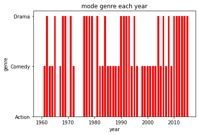

```python
bar_plot(df2.index, df2[('genres2','mode')], 'year', 'genre', "mode genre each year", 0.7, color='r')
```

### Let's see the changes in popularity from 1960 to 2015

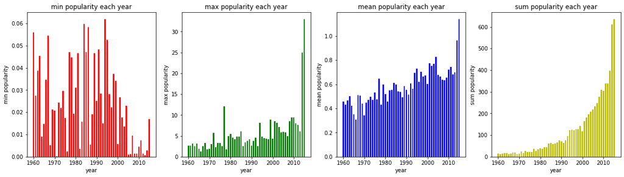

```python
plt.figure(figsize=(20,5))

plt.subplot(1,4,1)
bar_plot(df2.index, df2[('popularity', 'min')], 'year', 'min popularity', "min popularity each year", 0.7, color='r')

plt.subplot(1,4,2)
bar_plot(df2.index, df2[('popularity', 'max')], 'year', 'max popularity', "max popularity each year", 0.7, color='g')

plt.subplot(1,4,3)
bar_plot(df2.index, df2[('popularity', 'mean')], 'year', 'mean popularity', "mean popularity each year", 0.7, color='b')

plt.subplot(1,4,4)
bar_plot(df2.index, df2[('popularity', 'sum')], 'year', 'sum popularity', "sum popularity each year", 0.7, color='y')

plt.show()
```

### From those graph we can find some conclusions:

> 1. Min popularity decreased after 2004.
> 2. Max popularity increased a little bit each year. and it increased by high value last 2 years(2014-2015)
> 3. Mean popularity increased a little bit each year.
> 4. Total popularity is increasing by high ratio each year.

### Let's see the changes in number of movies and number of succeeded and failed movies from 1960 to 2015

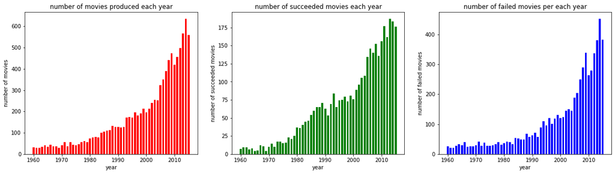

```python
plt.figure(figsize=(20,5))

plt.subplot(1,3,1)
bar_plot(df2.index, df2[('original_title', 'count')], 'year', 'number of movies', "number of movies produced each year", 0.7, color='r')

plt.subplot(1,3,2)
bar_plot(df2.index, df2[('succeeded_movie', 'sum')], 'year', 'number of succeeded movies', "number of succeeded movies each year", 0.7, color='g')

plt.subplot(1,3,3)
bar_plot(df2.index, df2['failed_movies'], 'year', 'number of failed movies', "number of failed movies per each year", 0.7, color='b')

plt.show()
```

### Let's see the changes in budget from 1960 to 2015

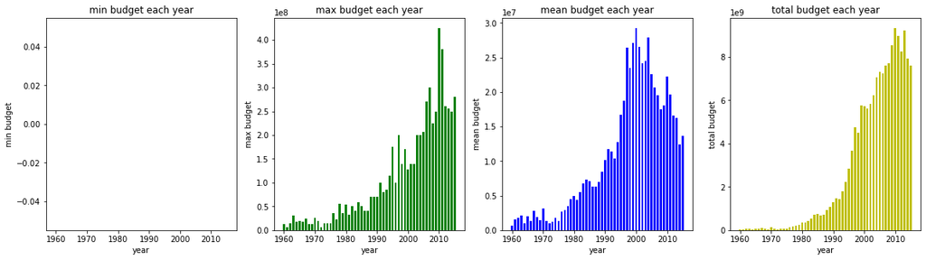

```python
plt.figure(figsize=(20,5))

plt.subplot(1,4,1)
bar_plot(df2.index, df2[('budget', 'min')], 'year', 'min budget', "min budget each year", 0.7, color='r')

plt.subplot(1,4,2)
bar_plot(df2.index, df2[('budget', 'max')], 'year', 'max budget', "max budget each year", 0.7, color='g')

plt.subplot(1,4,3)
bar_plot(df2.index, df2[('budget', 'mean')], 'year', 'mean budget', "mean budget each year", 0.7, color='b')

plt.subplot(1,4,4)
bar_plot(df2.index, df2[('budget', 'sum')], 'year', 'total budget', "total budget each year", 0.7, color='y')

plt.show()
```

### From those graph we can find some conclusions:

> 1. First we can not trust those values as there are many values of budgets are zero.
> 2. Because of the many zeros , there is at least a zero each year so the min budget appearing here is zero for all (thats not right of course)
> 3. We can not say that max budget each year is increasing then decreasing after 2008 , because there may be missing values after 2008, same for mean and total.
> 4. But anyway there are increasing in budget each year , and thats because of the increasing in number of produced movies.

### Let's see the changes in revenue from 1960 to 2015

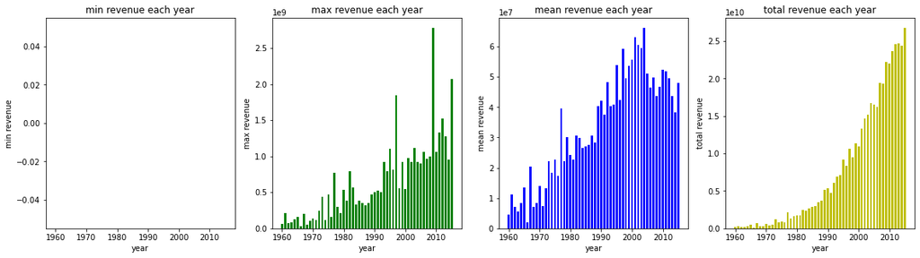

```python
plt.figure(figsize=(20,5))

plt.subplot(1,4,1)
bar_plot(df2.index, df2[('revenue', 'min')], 'year', 'min revenue', "min revenue each year", 0.7, color='r')

plt.subplot(1,4,2)
bar_plot(df2.index, df2[('revenue', 'max')], 'year', 'max revenue', "max revenue each year", 0.7, color='g')

plt.subplot(1,4,3)
bar_plot(df2.index, df2[('revenue', 'mean')], 'year', 'mean revenue', "mean revenue each year", 0.7, color='b')

plt.subplot(1,4,4)
bar_plot(df2.index, df2[('revenue', 'sum')], 'year', 'total revenue', "total revenue each year", 0.7, color='y')

plt.show()
```

### The same problems and conclusions of the budgets.

### Let's see the changes in the difference between revenues and budgets from 1960 to 2015

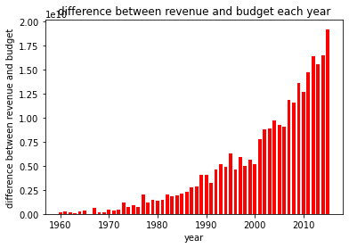

```python
bar_plot(df2.index, df2['revenue_budget_diff'], 'year', 'difference between revenue and budget', "difference between revenue and budget each year", 0.7, color='r')
```

### Let's see the changes in number of votes from 1960 to 2015

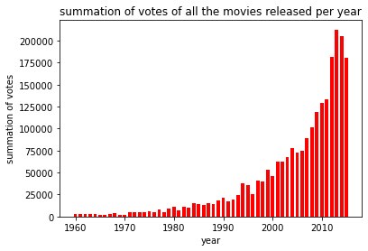

```python
bar_plot(df2.index, df2[('vote_count','sum')], 'year', 'summation of votes', "summation of votes of all the movies released per year", 0.7, color='r')
```

### Let's see the changes in runtime from 1960 to 2015

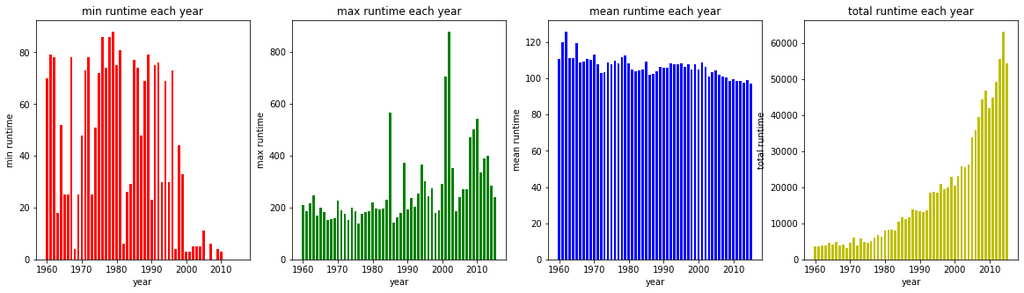

```python
plt.figure(figsize=(20,5))

plt.subplot(1,4,1)
bar_plot(df2.index, df2[('runtime', 'min')], 'year', 'min runtime', "min runtime each year", 0.7, color='r')

plt.subplot(1,4,2)
bar_plot(df2.index, df2[('runtime', 'max')], 'year', 'max runtime', "max runtime each year", 0.7, color='g')

plt.subplot(1,4,3)
bar_plot(df2.index, df2[('runtime', 'mean')], 'year', 'mean runtime', "mean runtime each year", 0.7, color='b')

plt.subplot(1,4,4)
bar_plot(df2.index, df2[('runtime', 'sum')], 'year', 'total runtime', "total runtime each year", 0.7, color='y')

plt.show()
```

### From those graph we can find some conclusions:

> 1. Min runtime decreased after 1999.
> 2. Max runtime increased a little bit each year.
> 3. Mean runtime decreased a little bit each year.
> 4. Total runtime is increasing by high ratio each year.

### Let's see the changes in average votes from 1960 to 2015

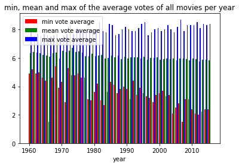

```python
width=0.3
plt.figure()
plt.bar(df2.index, df2[('vote_average', 'min')], width, color='r', alpha=1, label='min vote average')
plt.bar(df2.index + width, df2[('vote_average', 'mean')], width, color='g', alpha=1, label='mean vote average')
plt.bar(df2.index + width*2, df2[('vote_average', 'max')], width, color='b', alpha=1, label='max vote average')
plt.title('min, mean and max of the average votes of all movies per year')
plt.xlabel('year')
plt.legend()
```

### It is more complicated here , we can see every one alone

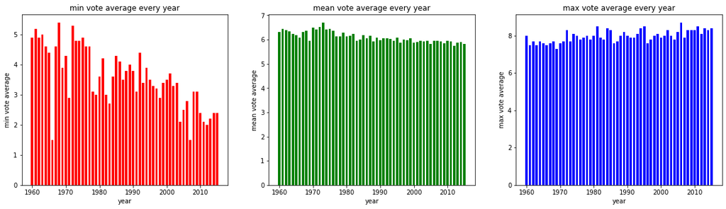

```python
plt.figure(figsize=(20,5))

plt.subplot(1,3,1)
bar_plot(df2.index, df2[('vote_average', 'min')], 'year', 'min vote average', "min vote average every year", 0.7, color='r')

plt.subplot(1,3,2)
bar_plot(df2.index, df2[('vote_average', 'mean')], 'year', 'mean vote average', "mean vote average every year", 0.7, color='g')

plt.subplot(1,3,3)
bar_plot(df2.index, df2[('vote_average', 'max')], 'year', 'max vote average', "max vote average every year", 0.7, color='b')

plt.show()
```

### Also we can use a style that makes high values have red color to see that as we go newer in years most of the parameters are increasing

#### Thats will make a summary of what we have done above.

```python
df2.style.background_gradient('Reds')
```

| release_year | popularity min | popularity max | popularity mean | popularity sum | original_title count | succeeded_movie sum | budget min | budget max | budget mean | budget sum | revenue min | revenue max | revenue mean | revenue sum | vote_count sum | runtime min | runtime max | runtime mean | runtime sum | vote_average min | vote_average max | vote_average mean | genres2 mode | failed_movies | revenue_budget_diff |
| --- | --- | --- | --- | --- | --- | --- | --- | --- | --- | --- | --- | --- | --- | --- | --- | --- | --- | --- | --- | --- | --- | --- | --- | --- | --- |
| 1960 | 0.055821 | 2.610362 | 0.458932 | 14.685834 | 32 | 7 | 0 | 12000000 | 689279.625000 | 22056948 | 0 | 60000000 | 4531406.250000 | 145005000 | 2481 | 70 | 208 | 110.656250 | 3541 | 4.900000 | 8.000000 | 6.325000 | Action | 25 | 122948052 |
| 1961 | 0.027527 | 2.631987 | 0.430438 | 12.913146 | 30 | 9 | 0 | 6000000 | 1537900.000000 | 46137000 | 0 | 215880014 | 11257339.600000 | 337720188 | 2395 | 79 | 186 | 119.866667 | 3596 | 5.200000 | 7.500000 | 6.433333 | Comedy | 21 | 291583188 |
| 1962 | 0.038819 | 3.170651 | 0.465245 | 13.957338 | 30 | 9 | 0 | 15000000 | 1824070.866667 | 54722126 | 0 | 70000000 | 7185994.866667 | 215579846 | 2364 | 78 | 216 | 125.833333 | 3775 | 4.900000 | 7.700000 | 6.386667 | Drama | 21 | 160857720 |
| 1963 | 0.045417 | 2.508235 | 0.502706 | 17.092019 | 34 | 6 | 0 | 31115000 | 2156808.823529 | 73331500 | 0 | 78898765 | 5511911.441176 | 187404989 | 2816 | 18 | 248 | 111.323529 | 3785 | 5.000000 | 7.500000 | 6.329412 | Comedy | 28 | 114073489 |
| 1964 | 0.008990 | 3.153791 | 0.421091 | 17.264746 | 41 | 8 | 0 | 17000000 | 963003.926829 | 39483161 | 0 | 124900000 | 8316628.829268 | 340981782 | 3126 | 52 | 170 | 111.195122 | 4559 | 4.600000 | 7.700000 | 6.224390 | Comedy | 33 | 301498621 |
| 1965 | 0.014759 | 1.910465 | 0.352522 | 11.985759 | 34 | 4 | 0 | 20000000 | 2064856.323529 | 70205115 | 0 | 163214286 | 13472995.705882 | 458081854 | 1810 | 25 | 199 | 119.294118 | 4056 | 4.400000 | 7.600000 | 6.188235 | Drama | 30 | 387876739 |
| 1966 | 0.034555 | 1.227582 | 0.308457 | 13.572123 | 44 | 5 | 0 | 18000000 | 1308063.636364 | 57554800 | 0 | 33736689 | 1925833.840909 | 84736689 | 1422 | 25 | 182 | 108.590909 | 4778 | 1.500000 | 7.500000 | 6.086364 | Action | 39 | 27181889 |
| 1967 | 0.054432 | 2.550704 | 0.511007 | 18.396240 | 36 | 12 | 0 | 25000000 | 2795888.888889 | 100652000 | 0 | 205843612 | 20495406.583333 | 737834637 | 3046 | 78 | 152 | 109.416667 | 3939 | 4.600000 | 7.600000 | 6.319444 | Comedy | 24 | 637182637 |
| 1968 | 0.005265 | 3.309196 | 0.506612 | 18.744652 | 37 | 11 | 0 | 12000000 | 1944297.297297 | 71939000 | 0 | 56715371 | 7154945.405405 | 264732980 | 4194 | 4 | 155 | 110.540541 | 4090 | 5.400000 | 7.700000 | 6.370270 | Drama | 26 | 192793980 |
| 1969 | 0.021121 | 1.778746 | 0.441299 | 12.797661 | 29 | 4 | 0 | 12000000 | 1452727.137931 | 42129087 | 0 | 102308889 | 8412312.965517 | 243957076 | 1702 | 25 | 158 | 110.310345 | 3199 | 3.900000 | 7.300000 | 5.944828 | Drama | 25 | 201827989 |
| 1970 | 0.020760 | 1.936962 | 0.341638 | 13.665514 | 40 | 10 | 0 | 25485000 | 3174048.650000 | 126961946 | 0 | 136400000 | 14005549.225000 | 560221969 | 2001 | 48 | 225 | 113.075000 | 4523 | 4.300000 | 7.600000 | 6.502500 | Action | 30 | 433260023 |
| 1971 | 0.000188 | 3.072555 | 0.448112 | 24.646153 | 55 | 14 | 0 | 20000000 | 1381763.636364 | 75997000 | 0 | 116000000 | 7362011.090909 | 404910610 | 5081 | 73 | 189 | 107.727273 | 5925 | 2.900000 | 7.700000 | 6.420000 | Drama | 41 | 328913610 |
| 1972 | 0.024345 | 5.738034 | 0.469449 | 17.369621 | 37 | 10 | 0 | 6000000 | 980520.378378 | 36279254 | 0 | 245066411 | 13371085.702703 | 494730171 | 5397 | 78 | 175 | 103.027027 | 3812 | 5.300000 | 8.300000 | 6.524324 | Comedy | 27 | 458450917 |
| 1973 | 0.021941 | 2.272486 | 0.494462 | 27.195419 | 55 | 17 | 0 | 15000000 | 1185286.963636 | 65190783 | 0 | 441306145 | 22254201.854545 | 1223981102 | 5173 | 25 | 151 | 103.527273 | 5694 | 4.800000 | 7.700000 | 6.703636 | Action | 38 | 1158790319 |
| 1974 | 0.029670 | 3.264571 | 0.469544 | 20.659918 | 44 | 17 | 0 | 14000000 | 1749318.181818 | 76970000 | 0 | 119500000 | 18466814.045455 | 812539818 | 5164 | 51 | 200 | 108.659091 | 4781 | 4.800000 | 8.100000 | 6.404545 | Action | 27 | 735569818 |
| 1975 | 0.017468 | 3.258151 | 0.533266 | 22.397183 | 42 | 15 | 0 | 15000000 | 1339976.190476 | 56279000 | 0 | 470654000 | 22797380.142857 | 957489966 | 6063 | 72 | 184 | 107.714286 | 4524 | 4.900000 | 8.000000 | 6.452381 | Action | 27 | 901210966 |
| 1976 | 0.002381 | 2.582657 | 0.476533 | 21.920529 | 46 | 16 | 0 | 35000000 | 2655434.782609 | 122150000 | 0 | 161000000 | 17413165.217391 | 801005600 | 4710 | 86 | 139 | 109.956522 | 5058 | 4.600000 | 7.800000 | 6.371739 | Drama | 30 | 678855600 |
| 1977 | 0.046957 | 12.037933 | 0.647046 | 35.587529 | 55 | 23 | 0 | 22000000 | 2937818.181818 | 161580000 | 0 | 775398007 | 39646966.527273 | 2180583159 | 8009 | 74 | 177 | 108.327273 | 5958 | 4.600000 | 7.900000 | 6.141818 | Drama | 32 | 2019003159 |
| 1978 | 0.044675 | 1.697618 | 0.430003 | 26.230174 | 61 | 21 | 0 | 55000000 | 3426180.508197 | 208997011 | 0 | 300218018 | 22186666.540984 | 1353386659 | 4815 | 86 | 183 | 111.573770 | 6806 | 3.100000 | 8.000000 | 6.139344 | Drama | 40 | 1144389648 |
| 1979 | 0.019263 | 4.935897 | 0.597555 | 33.463055 | 56 | 25 | 0 | 35000000 | 4550250.000000 | 254814000 | 0 | 210300000 | 30085623.446429 | 1684794913 | 8816 | 88 | 184 | 112.625000 | 6307 | 3.000000 | 7.800000 | 6.296429 | Drama | 31 | 1429980913 |
| 1980 | 0.031133 | 5.488441 | 0.519920 | 37.954180 | 73 | 37 | 0 | 54000000 | 4965753.424658 | 362500000 | 0 | 538400000 | 24228251.876712 | 1768662387 | 10831 | 75 | 219 | 108.424658 | 7915 | 3.600000 | 8.000000 | 6.145205 | Action | 36 | 1406162387 |
| 1981 | 0.046679 | 4.578300 | 0.455818 | 35.553775 | 78 | 36 | 0 | 32000000 | 4343048.538462 | 338757786 | 0 | 389925971 | 22751362.000000 | 1774606236 | 7403 | 81 | 195 | 105.064103 | 8195 | 4.200000 | 8.500000 | 6.152564 | Drama | 42 | 1435848450 |
| 1982 | 0.003659 | 4.215642 | 0.547968 | 43.837470 | 80 | 40 | 0 | 50000000 | 5472437.525000 | 437795002 | 0 | 792910554 | 30730548.150000 | 2458443852 | 11372 | 6 | 191 | 104.037500 | 8323 | 3.000000 | 7.900000 | 6.230000 | Comedy | 40 | 2020648850 |
| 1983 | 0.015727 | 4.828854 | 0.555111 | 42.743561 | 77 | 45 | 0 | 40600000 | 6727368.987013 | 518007412 | 0 | 572700000 | 29967913.246753 | 2307529320 | 9823 | 26 | 197 | 104.389610 | 8038 | 2.700000 | 7.800000 | 5.951948 | Comedy | 32 | 1789521908 |
| 1984 | 0.059713 | 4.831966 | 0.611105 | 60.499364 | 99 | 46 | 0 | 58000000 | 7365777.414141 | 729211964 | 0 | 333000000 | 26621458.767677 | 2635524418 | 15237 | 29 | 229 | 104.868687 | 10382 | 3.600000 | 8.400000 | 6.010101 | Drama | 53 | 1906312454 |
| 1985 | 0.047123 | 6.095293 | 0.596628 | 63.242541 | 106 | 54 | 0 | 50000000 | 7063402.235849 | 748720637 | 0 | 381109762 | 27129928.226415 | 2875772392 | 13721 | 77 | 566 | 109.433962 | 11600 | 4.300000 | 8.300000 | 6.184906 | Comedy | 52 | 2127051755 |
| 1986 | 0.058402 | 2.485419 | 0.541604 | 59.034876 | 109 | 60 | 0 | 40000000 | 6364322.137615 | 693711113 | 0 | 356830601 | 27505202.394495 | 2998067061 | 13446 | 74 | 142 | 102.165138 | 11136 | 4.100000 | 7.600000 | 6.060550 | Comedy | 49 | 2304355948 |
| 1987 | 0.005529 | 3.474728 | 0.535698 | 60.533928 | 113 | 65 | 0 | 40000000 | 6278370.008850 | 709455811 | 0 | 320145693 | 30638095.991150 | 3462104847 | 14866 | 48 | 163 | 102.318584 | 11562 | 3.500000 | 7.700000 | 6.149558 | Comedy | 48 | 2752649036 |
| 1988 | 0.019075 | 3.777441 | 0.491846 | 64.923629 | 132 | 65 | 0 | 70000000 | 6991272.727273 | 922848000 | 0 | 354825435 | 28325464.848485 | 3738961360 | 14333 | 69 | 180 | 104.037879 | 13733 | 3.800000 | 8.000000 | 5.931061 | Comedy | 67 | 2816113360 |
| 1989 | 0.046709 | 4.143585 | 0.585155 | 74.899807 | 128 | 71 | 0 | 70000000 | 8434815.312500 | 1079656360 | 0 | 474171806 | 40350966.546875 | 5164923718 | 18462 | 79 | 372 | 106.250000 | 13600 | 4.000000 | 8.200000 | 6.072656 | Comedy | 57 | 4085267358 |
| 1990 | 0.024987 | 2.679627 | 0.553660 | 69.761107 | 126 | 63 | 0 | 70000000 | 10145666.865079 | 1278354025 | 0 | 505000000 | 42100703.801587 | 5304688679 | 21477 | 23 | 192 | 105.880952 | 13341 | 3.800000 | 8.000000 | 5.967460 | Drama | 63 | 4026334654 |
| 1991 | 0.048237 | 3.852269 | 0.515138 | 64.392295 | 125 | 53 | 0 | 100000000 | 11729864.000000 | 1466233000 | 0 | 520000000 | 37652798.368000 | 4706599796 | 16857 | 75 | 236 | 105.768000 | 13221 | 3.100000 | 7.900000 | 6.050400 | Drama | 72 | 3240366796 |
| 1992 | 0.028515 | 4.586426 | 0.606111 | 76.369949 | 126 | 69 | 0 | 80000000 | 11375599.507937 | 1433325538 | 0 | 504050219 | 48239311.246032 | 6078153217 | 19265 | 76 | 202 | 108.182540 | 13631 | 4.400000 | 7.900000 | 6.046825 | Drama | 57 | 4644827679 |
| 1993 | 0.014992 | 2.571339 | 0.560883 | 96.471923 | 172 | 84 | 0 | 85000000 | 10335050.308140 | 1777628653 | 0 | 920100000 | 40419671.505814 | 6952183499 | 24199 | 30 | 254 | 107.744186 | 18532 | 3.400000 | 8.100000 | 6.038953 | Drama | 88 | 5174554846 |
| 1994 | 0.061916 | 8.093754 | 0.696182 | 121.135741 | 174 | 65 | 0 | 115000000 | 12759810.528736 | 2220207032 | 0 | 788241776 | 40753324.155172 | 7091078403 | 37342 | 69 | 366 | 107.850575 | 18766 | 3.900000 | 8.400000 | 5.940230 | Comedy | 109 | 4870871371 |
| 1995 | 0.052554 | 4.765359 | 0.728288 | 123.808879 | 170 | 74 | 0 | 175000000 | 16658143.394118 | 2831884377 | 0 | 1106279658 | 53807432.594118 | 9147263541 | 35696 | 30 | 300 | 108.335294 | 18417 | 3.500000 | 8.500000 | 6.072353 | Drama | 96 | 6315379164 |
| 1996 | 0.028143 | 4.480733 | 0.618728 | 121.270649 | 196 | 75 | 0 | 100000000 | 18730000.000000 | 3671080000 | 0 | 816969268 | 42366643.214286 | 8303862070 | 25789 | 73 | 242 | 106.336735 | 20842 | 3.300000 | 7.600000 | 5.867857 | Comedy | 121 | 4632782070 |
| 1997 | 0.022145 | 4.355219 | 0.703757 | 126.676286 | 180 | 79 | 0 | 200000000 | 26394925.972222 | 4751086675 | 0 | 1845034188 | 59193886.611111 | 10654899590 | 40731 | 4 | 273 | 107.594444 | 19367 | 3.200000 | 7.800000 | 5.997778 | Action | 101 | 5903812915 |
| 1998 | 0.037178 | 4.180540 | 0.662964 | 126.626105 | 191 | 73 | 0 | 140000000 | 23524397.905759 | 4493160000 | 0 | 553799566 | 49653752.874346 | 9483866799 | 39630 | 44 | 178 | 104.774869 | 20012 | 2.900000 | 8.000000 | 5.983246 | Comedy | 118 | 4990706799 |
| 1999 | 0.034182 | 8.947905 | 0.673304 | 142.740512 | 212 | 81 | 0 | 170000000 | 27100165.594340 | 5745235106 | 0 | 924317558 | 53564681.976415 | 11355712579 | 53247 | 33 | 189 | 107.650943 | 22822 | 3.400000 | 8.100000 | 6.052358 | Comedy | 131 | 5610477473 |
| 2000 | 0.005784 | 4.271452 | 0.601602 | 117.914036 | 196 | 76 | 0 | 127500000 | 29266326.530612 | 5736200000 | 0 | 546388105 | 55709286.765306 | 10919020206 | 45531 | 3 | 292 | 104.750000 | 20531 | 3.500000 | 7.900000 | 5.866837 | Comedy | 120 | 5182820206 |
| 2001 | 0.026783 | 8.575419 | 0.771896 | 163.642052 | 212 | 89 | 0 | 140000000 | 26504853.773585 | 5619029000 | 0 | 976475550 | 63017774.367925 | 13359768166 | 62447 | 3 | 705 | 108.990566 | 23106 | 3.700000 | 8.000000 | 5.907547 | Comedy | 123 | 7740739166 |
| 2002 | 0.017708 | 8.095275 | 0.750044 | 180.760677 | 241 | 96 | 0 | 140000000 | 24181079.896266 | 5827640255 | 0 | 926287400 | 60648309.161826 | 14616242508 | 62392 | 5 | 877 | 106.518672 | 25671 | 3.300000 | 8.300000 | 5.950207 | Comedy | 145 | 8788602253 |
| 2003 | 0.013546 | 7.122455 | 0.768583 | 195.220074 | 254 | 105 | 0 | 200000000 | 24511249.582677 | 6225857394 | 0 | 1118888979 | 59563472.322835 | 15129121970 | 67884 | 5 | 352 | 100.818898 | 25608 | 3.400000 | 8.000000 | 5.925197 | Comedy | 149 | 8903264576 |
| 2004 | 0.022891 | 5.827781 | 0.825507 | 208.853145 | 253 | 108 | 0 | 200000000 | 27948973.209486 | 7071090222 | 0 | 919838758 | 66195538.936759 | 16747471351 | 78044 | 5 | 184 | 103.632411 | 26219 | 2.100000 | 7.800000 | 5.963636 | Drama | 145 | 9676381129 |
| 2005 | 0.000973 | 5.939927 | 0.677563 | 218.852967 | 323 | 134 | 0 | 207000000 | 22582923.681115 | 7294284349 | 0 | 895921036 | 51100004.102167 | 16505301325 | 72404 | 11 | 240 | 104.470588 | 33744 | 2.500000 | 8.200000 | 5.820433 | Comedy | 189 | 9211016976 |
| 2006 | 0.001115 | 5.838503 | 0.665477 | 232.917076 | 350 | 146 | 0 | 270000000 | 20682243.714286 | 7238785300 | 0 | 1065659812 | 46432852.000000 | 16251498200 | 74502 | 0 | 270 | 101.937143 | 35678 | 2.800000 | 8.700000 | 5.939143 | Drama | 204 | 9012712900 |
| 2007 | 0.009512 | 4.965391 | 0.639138 | 248.624681 | 389 | 140 | 0 | 300000000 | 19503460.442159 | 7586846112 | 0 | 961000000 | 49881103.262211 | 19403749169 | 89266 | 6 | 270 | 101.028278 | 39300 | 1.500000 | 7.900000 | 5.944730 | Comedy | 249 | 11816903057 |
| 2008 | 0.001317 | 8.466668 | 0.631046 | 278.291458 | 441 | 152 | 0 | 225000000 | 17493792.736961 | 7714762597 | 0 | 1001921825 | 43761827.058957 | 19298965733 | 101085 | 0 | 470 | 100.430839 | 44290 | 3.100000 | 8.300000 | 5.925850 | Drama | 289 | 11584203136 |
| 2009 | 0.001423 | 9.432768 | 0.653179 | 309.606836 | 474 | 136 | 0 | 250000000 | 18039650.556962 | 8550794364 | 0 | 2781505847 | 46783091.044304 | 22175185155 | 118628 | 4 | 500 | 98.810127 | 46836 | 3.100000 | 8.300000 | 5.838397 | Comedy | 338 | 13624390791 |
| 2010 | 0.004569 | 9.363643 | 0.721896 | 303.196445 | 420 | 156 | 0 | 425000000 | 22218680.942857 | 9331845996 | 0 | 1063171911 | 52275381.240476 | 21955660121 | 128767 | 3 | 540 | 99.695238 | 41872 | 2.400000 | 8.300000 | 5.963095 | Drama | 264 | 12623814125 |
| 2011 | 0.007304 | 7.959228 | 0.744465 | 339.476015 | 456 | 177 | 0 | 380000000 | 19685502.717105 | 8976589239 | 0 | 1327817822 | 51948948.135965 | 23688720350 | 133696 | 0 | 336 | 98.442982 | 44890 | 2.100000 | 8.500000 | 5.932018 | Drama | 279 | 14712131111 |
| 2012 | 0.001372 | 7.637767 | 0.682239 | 339.754944 | 498 | 162 | 0 | 260000000 | 16581895.465863 | 8257783942 | 0 | 1519557910 | 49465305.891566 | 24633722334 | 181507 | 0 | 389 | 98.742972 | 49174 | 2.000000 | 8.100000 | 5.750602 | Drama | 336 | 16375938392 |
| 2013 | 0.000620 | 6.112766 | 0.701336 | 397.657582 | 567 | 187 | 0 | 255000000 | 16232133.617284 | 9203619761 | 0 | 1274219009 | 43564009.366843 | 24700793311 | 212569 | 0 | 400 | 97.698413 | 55395 | 2.200000 | 8.400000 | 5.863316 | Drama | 380 | 15497173550 |
| 2014 | 0.002922 | 24.949134 | 0.962285 | 611.051070 | 635 | 183 | 0 | 250000000 | 12454095.466142 | 7908350621 | 0 | 955119788 | 38314404.042520 | 24329646567 | 204842 | 0 | 285 | 99.308661 | 63061 | 2.400000 | 8.300000 | 5.886614 | Drama | 452 | 16421295946 |
| 2015 | 0.017050 | 32.985763 | 1.139736 | 635.972576 | 558 | 176 | 0 | 280000000 | 13605640.783154 | 7591947557 | 0 | 2068178225 | 47956853.172043 | 26759924070 | 180681 | 0 | 240 | 97.281362 | 54283 | 2.400000 | 8.400000 | 5.825627 | Drama | 382 | 19167976513 |

# Q2: What is the most popular months, most months having high budget and revenue ?

```python
# lets group our data in term of month
# and find the mean and count of some columns as
# original_title    >>>>    lets find it's count which indicates how many movies released on this month
# popularity        >>>>    lets find it's mean
# vote_count        >>>>    lets find it's mean
# budget            >>>>    lets find it's mean
# revenue           >>>>    lets find it's mean
# succeeded_movie   >>>>    lets find it's mean
# runtime           >>>>    lets find it's mean
# vote_average      >>>>    lets find it's mean

df3 = df.groupby('month').agg({'original_title':'count', 'popularity':'mean', 'vote_count':'mean', 'budget':'mean', 'revenue':'mean', 'succeeded_movie':'mean', 'runtime':'mean', 'vote_average':'mean'})
```

```python
## print our new dataframe is style of high values in col takes red color

df3.style.background_gradient('Reds')
```

| month | original_title | popularity | vote_count | budget | revenue | succeeded_movie | runtime | vote_average |
| --- | --- | --- | --- | --- | --- | --- | --- | --- |
| 1 | 747 | 0.523490 | 140.938420 | 8252730.066934 | 17283792.797858 | 0.283802 | 98.257028 | 5.810710 |
| 2 | 628 | 0.625916 | 192.550955 | 14674530.648089 | 31513633.507962 | 0.378981 | 101.519108 | 5.928662 |
| 3 | 739 | 0.694825 | 244.618403 | 16324767.274696 | 42429637.589986 | 0.395129 | 102.453315 | 5.926522 |
| 4 | 724 | 0.599827 | 207.276243 | 14425757.341160 | 36433579.254144 | 0.371547 | 100.657459 | 5.869199 |
| 5 | 741 | 0.801210 | 325.890688 | 21550599.577598 | 68072625.697706 | 0.395412 | 105.511471 | 5.980837 |
| 6 | 766 | 0.850622 | 349.822454 | 23473997.518277 | 80465392.588773 | 0.451697 | 103.147520 | 6.011097 |
| 7 | 714 | 0.813208 | 331.284314 | 21360083.463585 | 63477961.518207 | 0.443978 | 102.350140 | 5.928291 |
| 8 | 842 | 0.617720 | 174.186461 | 13104683.241093 | 30180061.350356 | 0.384798 | 99.428741 | 5.818765 |
| 9 | 1203 | 0.598890 | 174.757273 | 10221383.642560 | 21333216.441397 | 0.334996 | 104.968412 | 6.047298 |
| 10 | 1036 | 0.655249 | 205.815637 | 12520839.142857 | 28278276.422780 | 0.314672 | 100.947876 | 5.932336 |
| 11 | 736 | 0.804622 | 280.167120 | 20791838.845109 | 62351819.171196 | 0.379076 | 102.699728 | 6.058832 |
| 12 | 896 | 0.802915 | 289.286830 | 21666342.032366 | 64875144.505580 | 0.448661 | 111.183036 | 6.176562 |

### From this table we can get some conclusions

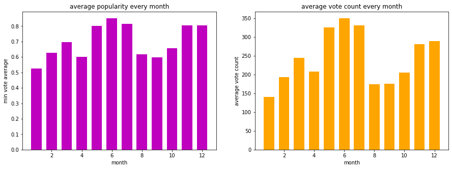

```python
plt.figure(figsize=(15,5))

plt.subplot(1,2,1)
bar_plot(df3.index, df3['popularity'], 'month', 'min vote average', "average popularity every month", 0.7, color='m')

plt.subplot(1,2,2)
bar_plot(df3.index, df3['vote_count'], 'month', 'average vote count', "average vote count every month", 0.7, color='orange')


plt.show()
```

### as we see, months 5,6,7,11,12 having higher popularity and votes.

# Q3: Whats is the movie that has the highest popularity of each year since 1960 ?

```python
# group our data by release year
# take index of movies having highest popularity each year
# locate them by the index

index = df.groupby('release_year')['popularity'].idxmax()
df.loc[index][['release_year','original_title','popularity']]
```

|  | release_year | original_title | popularity |
| --- | --- | --- | --- |
| 10141 | 1960 | Psycho | 2.610362 |
| 10110 | 1961 | One Hundred and One Dalmatians | 2.631987 |
| 9849 | 1962 | Dr. No | 3.170651 |
| 10438 | 1963 | From Russia With Love | 2.508235 |
| 9881 | 1964 | Goldfinger | 3.153791 |
| 10689 | 1965 | Thunderball | 1.910465 |
| 10820 | 1966 | How the Grinch Stole Christmas! | 1.227582 |
| 10398 | 1967 | The Jungle Book | 2.550704 |
| 9719 | 1968 | 2001: A Space Odyssey | 3.309196 |
| 10724 | 1969 | On Her Majesty's Secret Service | 1.778746 |
| 10648 | 1970 | The Aristocats | 1.936962 |
| 9923 | 1971 | A Clockwork Orange | 3.072555 |
| 7269 | 1972 | The Godfather | 5.738034 |
| 10593 | 1973 | Robin Hood | 2.272486 |
| 9758 | 1974 | The Godfather: Part II | 3.264571 |
| 9805 | 1975 | One Flew Over the Cuckoo's Nest | 3.258151 |
| 10173 | 1976 | Taxi Driver | 2.582657 |
| 1329 | 1977 | Star Wars | 12.037933 |
| 10755 | 1978 | Grease | 1.697618 |
| 7825 | 1979 | Alien | 4.935897 |
| 7309 | 1980 | The Empire Strikes Back | 5.488441 |
| 8375 | 1981 | Raiders of the Lost Ark | 4.578300 |
| 8888 | 1982 | Blade Runner | 4.215642 |
| 7987 | 1983 | Return of the Jedi | 4.828854 |
| 7882 | 1984 | The Terminator | 4.831966 |
| 6081 | 1985 | Back to the Future | 6.095293 |
| 10472 | 1986 | Aliens | 2.485419 |
| 9594 | 1987 | Predator | 3.474728 |
| 9449 | 1988 | Die Hard | 3.777441 |
| 9179 | 1989 | The Little Mermaid | 4.143585 |
| 9978 | 1990 | Total Recall | 2.679627 |
| 9316 | 1991 | Beauty and the Beast | 3.852269 |
| 8242 | 1992 | Reservoir Dogs | 4.586426 |
| 10220 | 1993 | Groundhog Day | 2.571339 |
| 4177 | 1994 | Pulp Fiction | 8.093754 |
| 8067 | 1995 | Se7en | 4.765359 |
| 8457 | 1996 | Independence Day | 4.480733 |
| 5231 | 1997 | Titanic | 4.355219 |
| 8969 | 1998 | The Truman Show | 4.180540 |
| 2409 | 1999 | Fight Club | 8.947905 |
| 8661 | 2000 | Gladiator | 4.271452 |
| 2633 | 2001 | The Lord of the Rings: The Fellowship of the Ring | 8.575419 |
| 3911 | 2002 | The Lord of the Rings: The Two Towers | 8.095275 |
| 4949 | 2003 | The Lord of the Rings: The Return of the King | 7.122455 |
| 6962 | 2004 | Harry Potter and the Prisoner of Azkaban | 5.827781 |
| 6190 | 2005 | Harry Potter and the Goblet of Fire | 5.939927 |
| 6554 | 2006 | Underworld: Evolution | 5.838503 |
| 7387 | 2007 | Pirates of the Caribbean: At World's End | 4.965391 |
| 2875 | 2008 | The Dark Knight | 8.466668 |
| 1386 | 2009 | Avatar | 9.432768 |
| 1919 | 2010 | Inception | 9.363643 |
| 3372 | 2011 | Captain America: The First Avenger | 7.959228 |
| 4361 | 2012 | The Avengers | 7.637767 |
| 5422 | 2013 | Frozen | 6.112766 |
| 629 | 2014 | Interstellar | 24.949134 |
| 0 | 2015 | Jurassic World | 32.985763 |

### Each row contains the year and the movie that took highest popularity in this year, and this popularity.

# Q4: Whats is the movie that has the highest revenue of each year since 1960 ?

```python
# group our data by release year
# take index of movies having highest revenue each year
# locate them by the index

index = df.groupby('release_year')['revenue'].idxmax()
df.loc[index][['release_year','original_title','revenue']]
```

|  | release_year | original_title | revenue |
| --- | --- | --- | --- |
| 10143 | 1960 | Spartacus | 60000000 |
| 10110 | 1961 | One Hundred and One Dalmatians | 215880014 |
| 9850 | 1962 | Lawrence of Arabia | 70000000 |
| 10438 | 1963 | From Russia With Love | 78898765 |
| 9881 | 1964 | Goldfinger | 124900000 |
| 10690 | 1965 | The Sound of Music | 163214286 |
| 10822 | 1966 | Who's Afraid of Virginia Woolf? | 33736689 |
| 10398 | 1967 | The Jungle Book | 205843612 |
| 9719 | 1968 | 2001: A Space Odyssey | 56715371 |
| 10725 | 1969 | Butch Cassidy and the Sundance Kid | 102308889 |
| 10654 | 1970 | Love Story | 136400000 |
| 9925 | 1971 | Diamonds Are Forever | 116000000 |
| 7269 | 1972 | The Godfather | 245066411 |
| 10594 | 1973 | The Exorcist | 441306145 |
| 9767 | 1974 | Blazing Saddles | 119500000 |
| 9806 | 1975 | Jaws | 470654000 |
| 10208 | 1976 | A Star Is Born | 161000000 |
| 1329 | 1977 | Star Wars | 775398007 |
| 10758 | 1978 | Superman | 300218018 |
| 7829 | 1979 | Moonraker | 210300000 |
| 7309 | 1980 | The Empire Strikes Back | 538400000 |
| 8375 | 1981 | Raiders of the Lost Ark | 389925971 |
| 8889 | 1982 | E.T. the Extra-Terrestrial | 792910554 |
| 7987 | 1983 | Return of the Jedi | 572700000 |
| 7883 | 1984 | Indiana Jones and the Temple of Doom | 333000000 |
| 6081 | 1985 | Back to the Future | 381109762 |
| 10475 | 1986 | Top Gun | 356830601 |
| 9613 | 1987 | Fatal Attraction | 320145693 |
| 9454 | 1988 | Rain Man | 354825435 |
| 9180 | 1989 | Indiana Jones and the Last Crusade | 474171806 |
| 9986 | 1990 | Ghost | 505000000 |
| 9317 | 1991 | Terminator 2: Judgment Day | 520000000 |
| 8243 | 1992 | Aladdin | 504050219 |
| 10223 | 1993 | Jurassic Park | 920100000 |
| 4180 | 1994 | The Lion King | 788241776 |
| 8094 | 1995 | The Net | 1106279658 |
| 8457 | 1996 | Independence Day | 816969268 |
| 5231 | 1997 | Titanic | 1845034188 |
| 8970 | 1998 | Armageddon | 553799566 |
| 2412 | 1999 | Star Wars: Episode I - The Phantom Menace | 924317558 |
| 8666 | 2000 | Mission: Impossible II | 546388105 |
| 2634 | 2001 | Harry Potter and the Philosopher's Stone | 976475550 |
| 3911 | 2002 | The Lord of the Rings: The Two Towers | 926287400 |
| 4949 | 2003 | The Lord of the Rings: The Return of the King | 1118888979 |
| 6977 | 2004 | Shrek 2 | 919838758 |
| 6190 | 2005 | Harry Potter and the Goblet of Fire | 895921036 |
| 6555 | 2006 | Pirates of the Caribbean: Dead Man's Chest | 1065659812 |
| 7387 | 2007 | Pirates of the Caribbean: At World's End | 961000000 |
| 2875 | 2008 | The Dark Knight | 1001921825 |
| 1386 | 2009 | Avatar | 2781505847 |
| 1930 | 2010 | Toy Story 3 | 1063171911 |
| 3374 | 2011 | Harry Potter and the Deathly Hallows: Part 2 | 1327817822 |
| 4361 | 2012 | The Avengers | 1519557910 |
| 5422 | 2013 | Frozen | 1274219009 |
| 634 | 2014 | The Hobbit: The Battle of the Five Armies | 955119788 |
| 3 | 2015 | Star Wars: The Force Awakens | 2068178225 |

### Each row contains the year and the movie that took highest revenue in this year, and this revenue

# Q5: Whats is the movie that has the highest budget of each year since 1960 ?

```python
# group our data by release year
# take index of movies having highest budget each year
# locate them by the index

index = df.groupby('release_year')['budget'].idxmax()
df.loc[index][['release_year','original_title','budget']]
```

|  | release_year | original_title | budget |
| --- | --- | --- | --- |
| 10143 | 1960 | Spartacus | 12000000 |
| 10112 | 1961 | West Side Story | 6000000 |
| 9850 | 1962 | Lawrence of Arabia | 15000000 |
| 10443 | 1963 | Cleopatra | 31115000 |
| 9887 | 1964 | My Fair Lady | 17000000 |
| 10716 | 1965 | The Greatest Story Ever Told | 20000000 |
| 10824 | 1966 | The Bible: In the Beginning... | 18000000 |
| 10409 | 1967 | The Dirty Dozen | 25000000 |
| 9719 | 1968 | 2001: A Space Odyssey | 12000000 |
| 10730 | 1969 | Battle of Britain | 12000000 |
| 10656 | 1970 | Tora! Tora! Tora! | 25485000 |
| 9931 | 1971 | Bedknobs and Broomsticks | 20000000 |
| 7269 | 1972 | The Godfather | 6000000 |
| 10593 | 1973 | Robin Hood | 15000000 |
| 9785 | 1974 | The Towering Inferno | 14000000 |
| 9836 | 1975 | The Hindenburg | 15000000 |
| 10218 | 1976 | The Bad News Bears | 35000000 |
| 1335 | 1977 | A Bridge Too Far | 22000000 |
| 10758 | 1978 | Superman | 55000000 |
| 7828 | 1979 | Star Trek: The Motion Picture | 35000000 |
| 7315 | 1980 | Superman II | 54000000 |
| 8397 | 1981 | Reds | 32000000 |
| 8920 | 1982 | Annie | 50000000 |
| 7993 | 1983 | Trading Places | 40600000 |
| 7927 | 1984 | The Cotton Club | 58000000 |
| 6109 | 1985 | Santa Claus: The Movie | 50000000 |
| 10483 | 1986 | Pirates | 40000000 |
| 9598 | 1987 | The Living Daylights | 40000000 |
| 9461 | 1988 | Who Framed Roger Rabbit | 70000000 |
| 9189 | 1989 | The Abyss | 70000000 |
| 9980 | 1990 | Die Hard 2 | 70000000 |
| 9317 | 1991 | Terminator 2: Judgment Day | 100000000 |
| 8245 | 1992 | Batman Returns | 80000000 |
| 10230 | 1993 | Last Action Hero | 85000000 |
| 4186 | 1994 | True Lies | 115000000 |
| 8089 | 1995 | Waterworld | 175000000 |
| 8464 | 1996 | The Hunchback of Notre Dame | 100000000 |
| 5231 | 1997 | Titanic | 200000000 |
| 8970 | 1998 | Armageddon | 140000000 |
| 2434 | 1999 | Wild Wild West | 170000000 |
| 8671 | 2000 | Dinosaur | 127500000 |
| 2642 | 2001 | Pearl Harbor | 140000000 |
| 3919 | 2002 | Men in Black II | 140000000 |
| 4959 | 2003 | Terminator 3: Rise of the Machines | 200000000 |
| 7012 | 2004 | Spider-Man 2 | 200000000 |
| 6215 | 2005 | King Kong | 207000000 |
| 6570 | 2006 | Superman Returns | 270000000 |
| 7387 | 2007 | Pirates of the Caribbean: At World's End | 300000000 |
| 2902 | 2008 | The Chronicles of Narnia: Prince Caspian | 225000000 |
| 1389 | 2009 | Harry Potter and the Half-Blood Prince | 250000000 |
| 2244 | 2010 | The Warrior's Way | 425000000 |
| 3375 | 2011 | Pirates of the Caribbean: On Stranger Tides | 380000000 |
| 4411 | 2012 | John Carter | 260000000 |
| 5508 | 2013 | The Lone Ranger | 255000000 |
| 634 | 2014 | The Hobbit: The Battle of the Five Armies | 250000000 |
| 14 | 2015 | Avengers: Age of Ultron | 280000000 |

### Each row contains the year and the movie that took highest budget in this year, and this budget

# Q6: Whats is the movie that has the highest vote of each year since 1960 ?

```python
# group our data by release year
# take index of movies having highest vote each year
# locate them by the index

index = df.groupby('release_year')['vote_average'].idxmax()
df.loc[index][['release_year','original_title','vote_average']]
```

|  | release_year | original_title | vote_average |
| --- | --- | --- | --- |
| 10141 | 1960 | Psycho | 8.0 |
| 10131 | 1961 | One, Two, Three | 7.5 |
| 9852 | 1962 | To Kill a Mockingbird | 7.7 |
| 10441 | 1963 | Charade | 7.5 |
| 9882 | 1964 | Dr. Strangelove or: How I Learned to Stop Worr... | 7.7 |
| 10693 | 1965 | A Charlie Brown Christmas | 7.6 |
| 10822 | 1966 | Who's Afraid of Virginia Woolf? | 7.5 |
| 10402 | 1967 | Bonnie and Clyde | 7.6 |
| 9719 | 1968 | 2001: A Space Odyssey | 7.7 |
| 10736 | 1969 | Kes | 7.3 |
| 10678 | 1970 | Gimme Shelter | 7.6 |
| 9923 | 1971 | A Clockwork Orange | 7.7 |
| 7269 | 1972 | The Godfather | 8.3 |
| 10601 | 1973 | The Sting | 7.7 |
| 9758 | 1974 | The Godfather: Part II | 8.1 |
| 9805 | 1975 | One Flew Over the Cuckoo's Nest | 8.0 |
| 10173 | 1976 | Taxi Driver | 7.8 |
| 1329 | 1977 | Star Wars | 7.9 |
| 10817 | 1978 | The Last Waltz | 8.0 |
| 7826 | 1979 | Apocalypse Now | 7.8 |
| 7309 | 1980 | The Empire Strikes Back | 8.0 |
| 8411 | 1981 | Queen - Rock Montreal | 8.5 |
| 8923 | 1982 | Vincent | 7.9 |
| 7987 | 1983 | Return of the Jedi | 7.8 |
| 7948 | 1984 | Stop Making Sense | 8.4 |
| 6176 | 1985 | Shoah | 8.3 |
| 10472 | 1986 | Aliens | 7.6 |
| 9595 | 1987 | Full Metal Jacket | 7.7 |
| 9549 | 1988 | The Thin Blue Line | 8.0 |
| 9315 | 1989 | For All Mankind | 8.2 |
| 9979 | 1990 | Goodfellas | 8.0 |
| 9335 | 1991 | The Silence of the Lambs | 7.9 |
| 8242 | 1992 | Reservoir Dogs | 7.9 |
| 10222 | 1993 | Schindler's List | 8.1 |
| 4178 | 1994 | The Shawshank Redemption | 8.4 |
| 8221 | 1995 | A Personal Journey with Martin Scorsese Throug... | 8.5 |
| 8459 | 1996 | Trainspotting | 7.6 |
| 5311 | 1997 | Geri's Game | 7.8 |
| 8987 | 1998 | American History X | 8.0 |
| 2409 | 1999 | Fight Club | 8.1 |
| 8662 | 2000 | Memento | 7.9 |
| 2722 | 2001 | Band of Brothers | 8.0 |
| 4164 | 2002 | The Century of the Self | 8.3 |
| 5209 | 2003 | Tupac: Resurrection | 8.0 |
| 6965 | 2004 | Eternal Sunshine of the Spotless Mind | 7.8 |
| 6441 | 2005 | Babam ve oÄŸlum | 8.2 |
| 6911 | 2006 | Pink Floyd: Pulse | 8.7 |
| 7711 | 2007 | The King of Kong | 7.9 |
| 3310 | 2008 | Dear Zachary: A Letter to a Son About His Father | 8.3 |
| 1864 | 2009 | Iron Maiden: Flight 666 | 8.3 |
| 2313 | 2010 | Tick Tock Tale | 8.3 |
| 3690 | 2011 | The Art of Flight | 8.5 |
| 4934 | 2012 | John Mulaney: New In Town | 8.1 |
| 5986 | 2013 | Guten Tag, RamÃ³n | 8.4 |
| 1322 | 2014 | One Direction: Where We Are - The Concert | 8.3 |
| 609 | 2015 | The Jinx: The Life and Deaths of Robert Durst | 8.4 |

### Each row contains the year and the movie that took highest vote in this year, and this vote

# Q7: What is the genre that has the highest movies released each year?

ref: https://stackoverflow.com/questions/15222754/groupby-pandas-dataframe-and-select-most-common-value or we can use what we did before in df2

```python
index = df.groupby('release_year')['genres2'].agg(lambda x:x.value_counts().index[0])
index
```

```
release_year
1960    Action
1961    Comedy
1962     Drama
1963    Comedy
1964    Comedy
1965     Drama
1966    Action
1967    Comedy
1968     Drama
1969     Drama
1970    Action
1971     Drama
1972    Comedy
1973    Action
```

[output cut: 43 more lines]

### Each row contains the year and the dominant genre this year.

# Q8 What is the relationship between vote average and popularity, and btween succeeded movies and popularity ?

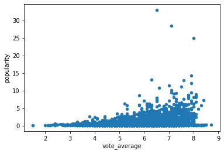

```python
df.plot(x='vote_average',y='popularity',kind='scatter')
```

### As vote average increases, popularity increase

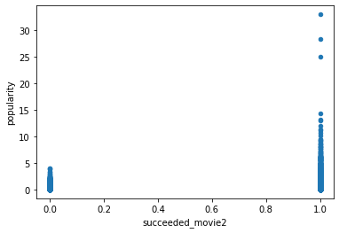

```python
df.plot(x='succeeded_movie2',y='popularity',kind='scatter')
```

## Limitations

> 1. There are many zeros values in important columns like budget and revenue.
> 2. There are some null values that when we removed them, our data is affected a little bit.
> 3. Genres column contains many genres, we used first genre only and ignore the other.
> 4. No information about the census of the world from 1960 to 2015.
> 5. No information about the number of cinemas from 1960 to 2015.